# Abortdata Weeks

Trine Thestrup Larsen and Mathilde Halberg Nielsen

2023-10-30

# Loading the packages we know we will need

```r
library(tidyverse)
library(readxl)

library(janitor)
```

#Loading the data We load the data the same way we did with the other datasets

```r
Abortdata_kopi <- read_excel("data/Abortdata-kopi.xlsx",
    sheet = "Tabel 3 - Svangerskabslængde",
    col_names = FALSE, skip = 1)
```

# Data transformation

We conclude that the data is not tidy for R to work with, so we start to make it tidy- We begin with cutting unwanted rows off

```r
Abortdata_kopi %>% slice(2:8) -> Abortdata_kopi
```

# The years as columnnames.

We use the following function from janitor

```r
Abortdata_kopi %>% row_to_names(row_number = 1) -> Abortdata_kopi
```

#More changes to the data We make columns with pivotlonger and give them names We convert the datatype into character and the Num_of_abortion into numeric Renaming an existing column

```r
Abortdata_kopi %>%
  mutate_if(is.numeric, as.character) %>%
  pivot_longer(cols = matches("\\d{4}"),
               names_to = "Year",
               values_to = "Num_of_abortion") %>%
  rename("Stage" = "År") %>%
  mutate(Num_of_abortion = as.numeric(Num_of_abortion))-> Abort_data_tidy
```

Making Stage into a factor, to alter the order

```r
Abort_data_tidy %>%
  count(Stage)
```

```
## # A tibble: 6 × 2
##   Stage                        n
##   <chr>                    <int>
## 1 0-7 fulde uger              50
## 2 12-17 fulde uger            50
## 3 18-21 fulde uger            50
## 4 22 fulde uger og derover    50
## 5 8-11 fulde uger             50
## 6 Ukendt                      50
```

# Creating order within the factor and use of this new factor

```r
Stage_levels <- c("0-7 fulde uger", "8-11 fulde uger", "12-17 fulde uger", "18-21 fulde uger", "22 fulde uger og derover", "Ukendt")


Abort_data_tidy %>%
  mutate(Stage = factor(Stage, levels = Stage_levels)) -> Abort_data_tidy
```

#Creating the ggplot, stacked bar plot, from the now tidy data

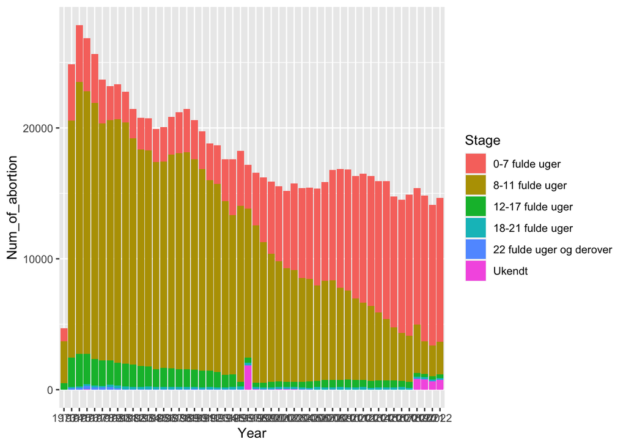

```r
ggplot(Abort_data_tidy, aes(fill=Stage, y=Num_of_abortion, x=Year)) +
    geom_bar(position="stack", stat="identity")
```

#Turning the years to make them readable

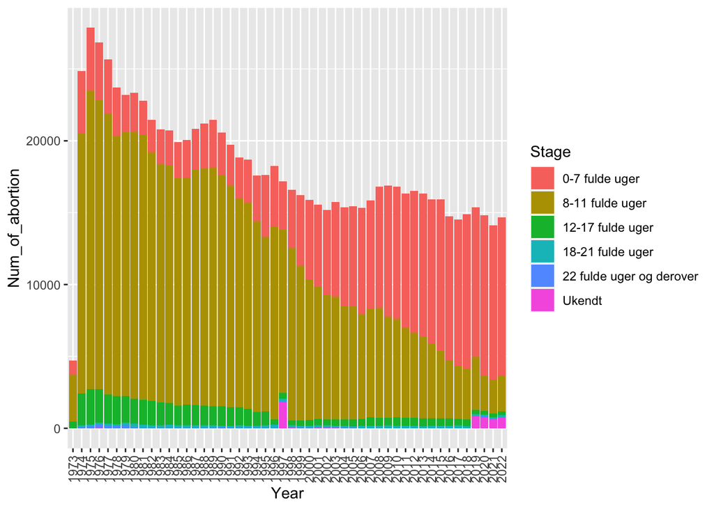

```r
ggplot(Abort_data_tidy, aes(fill=Stage, y=Num_of_abortion, x=Year)) +
    geom_bar(position="stack", stat="identity")+
    theme(axis.text.x = element_text(angle = 90, vjust = 0.5, hjust = 1))
```

#Making more space between the years, changing the colours and renaming We figured out that we needed to alter the years further, to be able to read it.

We would also like to change the colours. We wanted to use the same colour package as for the other graphs.

```r
library("wesanderson")
```

In this code we include the colourpallette, change the size of the font and rename the y-axis

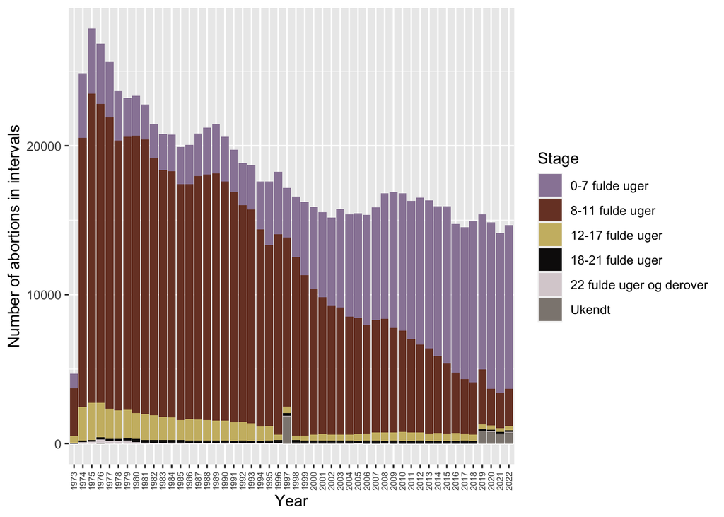

```r
ggplot(Abort_data_tidy, aes(fill=Stage, y=Num_of_abortion, x=Year)) +
    geom_bar(position="stack", stat="identity")+
    scale_fill_manual(values = wes_palette("IsleofDogs1"))+
    theme(axis.text.x = element_text(angle = 90, vjust = 0.5, hjust = 1, size = "6"))+
    ylab("Number of abortions in intervals")
```

#Changing the names of the intervals in the Stage column to english

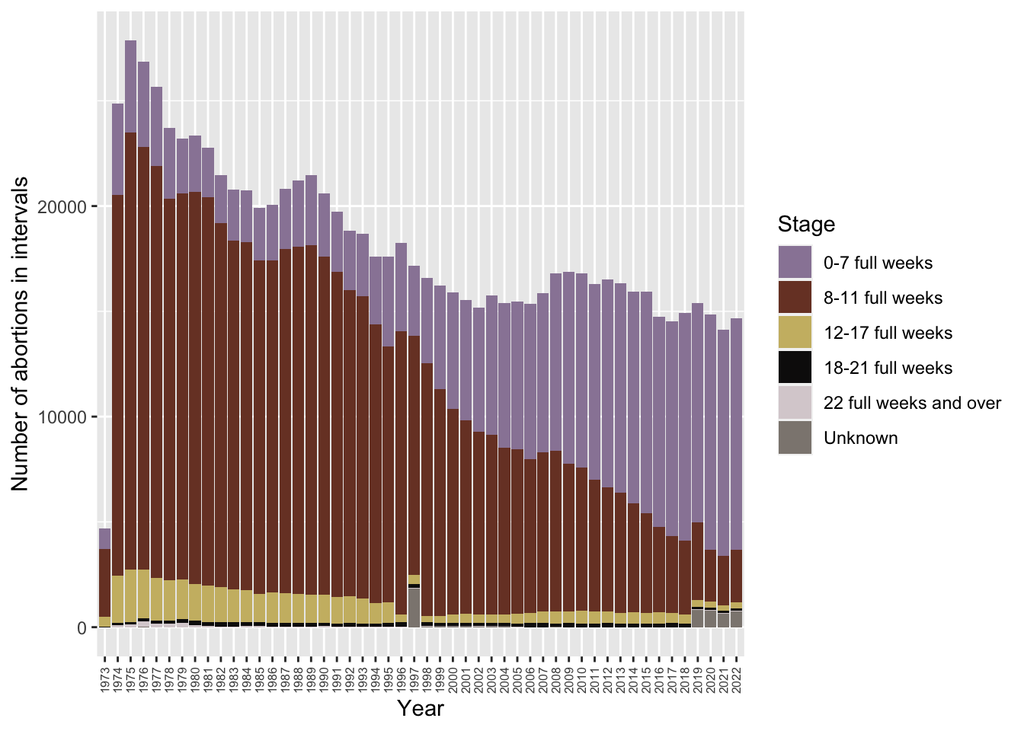

```r
ggplot(Abort_data_tidy, aes(fill=Stage, y=Num_of_abortion, x=Year)) +
    geom_bar(position="stack", stat="identity")+
    scale_fill_manual(values = wes_palette("IsleofDogs1"),
                      breaks = c("0-7 fulde uger", "8-11 fulde uger", "12-17 fulde uger", "18-21 fulde uger", "22 fulde uger og derover", "Ukendt"),
                      labels = c("0-7 full weeks", "8-11 full weeks", "12-17 full weeks", "18-21 full weeks", "22 full weeks and over", "Unknown"))+
    theme(axis.text.x = element_text(angle = 90, vjust = 0.5, hjust = 1, size = "6"))+
    ylab("Number of abortions in intervals")
```